# World wide natural disaster events — Analysis Report

Author

Ziaul Hoque

Published

September 29, 2026

### Approach

My goal is to work with this data and get insights information through data driven approach and analyze incidents in different locations worldwide and get more information & visualize data to improve emergency response plans, risk mitigation techniques and disaster preparedness. So data driven insights are essential for identifying susceptible areas and allocating resources as emergency needed.

### Data Sources

https://github.com/CandySoftInc/DATA607-Assignment1-Natural-Disaster-Events/blob/main/synthetic_disaster_events_2025.csv

### Research Question

How we can improve more awareness to people before any natural disaster happens and how we can prevent loss or degree of severity, number of victims through this analysis?

### Codebase

**Including all related library**

```r
library(tidyverse)
library(lubridate)
library(scales)
library(knitr)
```

**Import Dataset**

Loading dataset into dataframe to clean and preparing a dataset by modifying its columns into correct datatypes.

```r
data_file <- "synthetic_disaster_events_2025.csv"
data <- read_csv(data_file, show_col_types = FALSE) |>
  mutate(
    date = as.Date(date),
    disaster_type = factor(disaster_type),
    location = factor(location),
    aid_provided = factor(aid_provided, levels = c("No", "Yes")),
    is_major_disaster = as.logical(is_major_disaster)
  )

cat("Rows:", nrow(data), "  Columns:", ncol(data))
```

```
Rows: 20000   Columns: 13
```

Check Dataset Structure

```r
str(data)
```

```
tibble [20,000 × 13] (S3: tbl_df/tbl/data.frame)
 $ event_id                   : num [1:20000] 1 2 3 4 5 6 7 8 9 10 ...
 $ disaster_type              : Factor w/ 7 levels "Drought","Earthquake",..: 7 4 6 1 6 7 1 6 4 1 ...
 $ location                   : Factor w/ 8 levels "Chile","India",..: 1 2 4 1 7 3 2 5 7 8 ...
 $ latitude                   : num [1:20000] -34.7 22.1 42.3 -33.4 39.4 ...
 $ longitude                  : num [1:20000] -71.8 78 11 -70 37 ...
 $ date                       : Date[1:20000], format: "2025-08-27" "2023-05-29" ...
 $ severity_level             : num [1:20000] 8 5 7 8 8 9 7 7 4 4 ...
 $ affected_population        : num [1:20000] 31104 29340 34804 31191 46284 ...
 $ estimated_economic_loss_usd: num [1:20000] 2768213 5996227 9222541 1827703 13435921 ...
 $ response_time_hours        : num [1:20000] 5.12 44.43 49.3 65.56 60.96 ...
 $ aid_provided               : Factor w/ 2 levels "No","Yes": 2 1 1 2 1 2 2 2 1 2 ...
 $ infrastructure_damage_index: num [1:20000] 0.59 0.26 0.94 0.94 0.92 0.95 0.4 1 0.53 0.64 ...
 $ is_major_disaster          : logi [1:20000] TRUE FALSE TRUE TRUE TRUE TRUE ...
```

```r
head(data)
```

```
# A tibble: 6 × 13
  event_id disaster_type   location latitude longitude date       severity_level
     <dbl> <fct>           <fct>       <dbl>     <dbl> <date>              <dbl>
1        1 Wildfire        Chile      -34.7      -71.8 2025-08-27              8
2        2 Hurricane       India       22.1       78.0 2023-05-29              5
3        3 Volcanic Erupt… Italy       42.3       11.0 2023-01-15              7
4        4 Drought         Chile      -33.4      -70.0 2024-02-08              8
5        5 Volcanic Erupt… Turkey      39.4       37.0 2023-12-23              8
6        6 Wildfire        Indones…    -2.48     113.  2023-11-19              9
# ℹ 6 more variables: affected_population <dbl>,
#   estimated_economic_loss_usd <dbl>, response_time_hours <dbl>,
#   aid_provided <fct>, infrastructure_damage_index <dbl>,
#   is_major_disaster <lgl>
```

**Dataset Overview**

```r
overview <- tibble(
  Measure = c(
    "Number of events",
    "Number of variables",
    "Earliest event date",
    "Latest event date",
    "Total affected population",
    "Total estimated economic loss",
    "Average severity",
    "Average response time (hours)"
  ),
  Value = c(
    nrow(data),
    ncol(data),
    format(min(data$date, na.rm = TRUE), "%Y-%m-%d"),
    format(max(data$date, na.rm = TRUE), "%Y-%m-%d"),
    comma(sum(data$affected_population, na.rm = TRUE)),
    dollar(sum(data$estimated_economic_loss_usd, na.rm = TRUE)),
    round(mean(data$severity_level, na.rm = TRUE), 2),
    round(mean(data$response_time_hours, na.rm = TRUE), 2)
  )
)
kable(overview, caption = "Dataset overview")
```

Dataset overview

| Measure | Value |
| --- | --- |
| Number of events | 20000 |
| Number of variables | 13 |
| Earliest event date | 2022-12-08 |
| Latest event date | 2025-12-07 |
| Total affected population | 552,824,979 |
| Total estimated economic loss | $96,621,452,916 |
| Average severity | 5.49 |
| Average response time (hours) | 36.37 |

**Event Frequency**

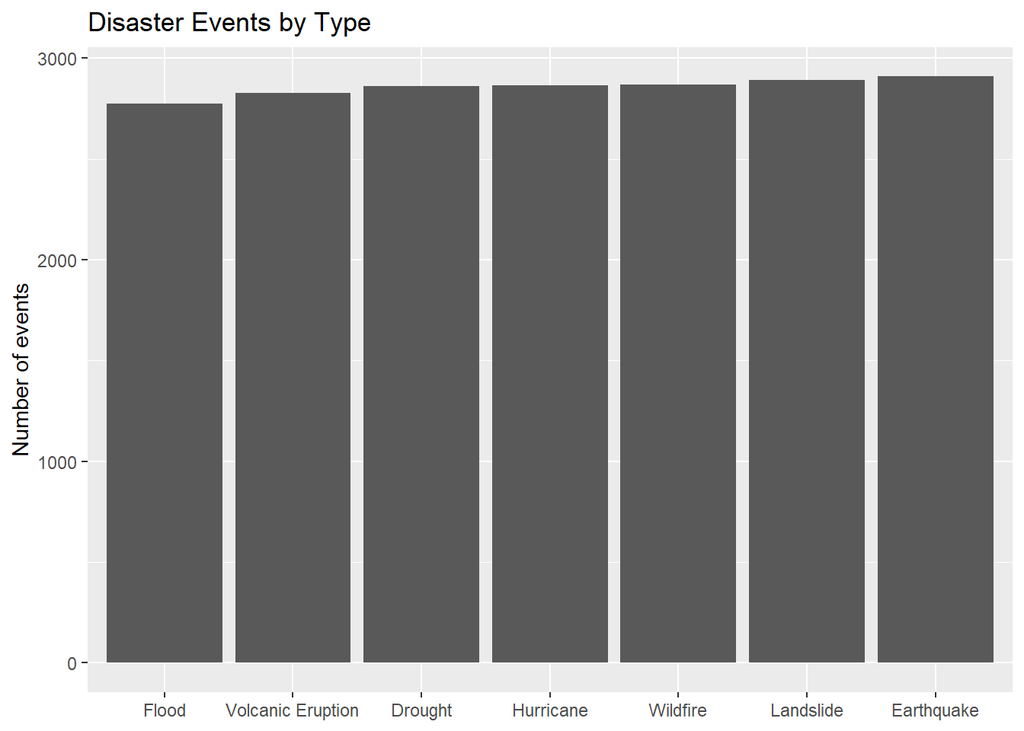

```r
events_by_type <- data %>% count(disaster_type, sort = TRUE)
ggplot(events_by_type, aes(y = reorder(disaster_type, n), x = n)) +
  geom_col() + coord_flip() +
  labs(y = NULL, x = "Number of events", title = "Disaster Events by Type")
```

```r
knitr::kable(events_by_type, col.names = c("Disaster type", "Events"))
```

| Disaster type | Events |
| --- | --- |
| Earthquake | 2910 |
| Landslide | 2891 |
| Wildfire | 2870 |
| Hurricane | 2866 |
| Drought | 2863 |
| Volcanic Eruption | 2827 |
| Flood | 2773 |

**Economic loss**

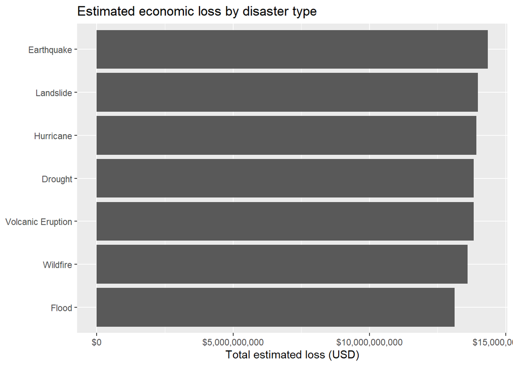

```r
loss_by_type <- data %>%
  group_by(disaster_type) %>%
  summarise(
    events = n(),
    total_loss_usd = sum(estimated_economic_loss_usd, na.rm = TRUE),
    mean_loss_usd = mean(estimated_economic_loss_usd, na.rm = TRUE),
    median_loss_usd = median(estimated_economic_loss_usd, na.rm = TRUE),
    .groups = "drop"
  ) %>% arrange(desc(total_loss_usd))

ggplot(loss_by_type, aes(x = reorder(disaster_type, total_loss_usd), y = total_loss_usd)) +
  geom_col() + coord_flip() + scale_y_continuous(labels = dollar_format()) +
  labs(x = NULL, y = "Total estimated loss (USD)", title = "Estimated economic loss by disaster type")
```

```r
knitr::kable(loss_by_type, digits = 0)
```

| disaster_type | events | total_loss_usd | mean_loss_usd | median_loss_usd |
| --- | --- | --- | --- | --- |
| Earthquake | 2910 | 14339311149 | 4927598 | 4104313 |
| Landslide | 2891 | 13981221492 | 4836120 | 4024796 |
| Hurricane | 2866 | 13916903531 | 4855863 | 4028622 |
| Drought | 2863 | 13831854096 | 4831245 | 4015134 |
| Volcanic Eruption | 2827 | 13820939149 | 4888907 | 4110298 |
| Wildfire | 2870 | 13602514413 | 4739552 | 3970607 |
| Flood | 2773 | 13128709086 | 4734479 | 3984243 |

**Major-disaster summary**

```r
major_summary <- data %>%
  group_by(is_major_disaster) %>%
  summarise(
    events = n(),
    avg_severity = mean(severity_level, na.rm = TRUE),
    avg_affected = mean(affected_population, na.rm = TRUE),
    avg_loss_usd = mean(estimated_economic_loss_usd, na.rm = TRUE),
    avg_response_hours = mean(response_time_hours, na.rm = TRUE),
    .groups = "drop"
  ) %>%
  mutate(category = if_else(is_major_disaster == 1, "Major disaster", "Other disaster")) %>%
  select(category, everything(), -is_major_disaster)
knitr::kable(major_summary, digits = 2)
```

| category | events | avg_severity | avg_affected | avg_loss_usd | avg_response_hours |
| --- | --- | --- | --- | --- | --- |
| Other disaster | 11999 | 3.49 | 17806.37 | 3107868 | 36.42 |
| Major disaster | 8001 | 8.48 | 42390.50 | 7415341 | 36.29 |

**Summary by location**

```r
location_summary <- data %>%
  group_by(location) %>%
  summarise(
    events = n(),
    total_affected = sum(affected_population, na.rm = TRUE),
    total_loss_usd = sum(estimated_economic_loss_usd, na.rm = TRUE),
    avg_severity = mean(severity_level, na.rm = TRUE),
    .groups = "drop"
  ) %>% arrange(desc(total_loss_usd))
knitr::kable(location_summary, digits = 2)
```

| location | events | total_affected | total_loss_usd | avg_severity |
| --- | --- | --- | --- | --- |
| India | 2583 | 72183422 | 12652716823 | 5.54 |
| Indonesia | 2530 | 70193413 | 12309428718 | 5.51 |
| Chile | 2515 | 70115117 | 12236377078 | 5.56 |
| Italy | 2485 | 69355495 | 12129163356 | 5.48 |
| USA | 2442 | 67448482 | 11940119463 | 5.48 |
| Philippines | 2453 | 67279471 | 11867675791 | 5.46 |
| Turkey | 2515 | 68387863 | 11804815025 | 5.46 |
| Japan | 2477 | 67861716 | 11681156662 | 5.43 |

#### My next Goal

Find relationships between among impact measures -

- Severity level vs. Economic loss and correlation coefficient value between these two factors.
- Response time vs. Affected population and correlation coefficient value between these two factors.